# **5. Simple Visualizations**

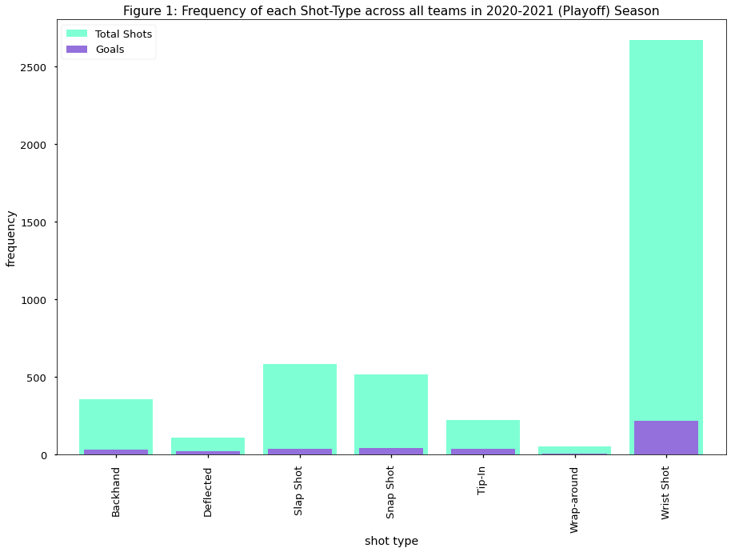

```python
with plt.style.context('seaborn-talk'):
    df_hist.plot(kind = 'bar', width = 0.8, figsize = (15, 10), color = 'aquamarine', label = "Total Shots")
    plt.bar(df_hist.index, goals, color = 'mediumpurple', width = 0.7, label = "Goals")
    plt.ylabel("frequency")
    plt.title("Figure 1: Frequency of each Shot-Type across all teams in 2020-2021 (Playoff) Season")
    plt.legend(loc='upper left')
```

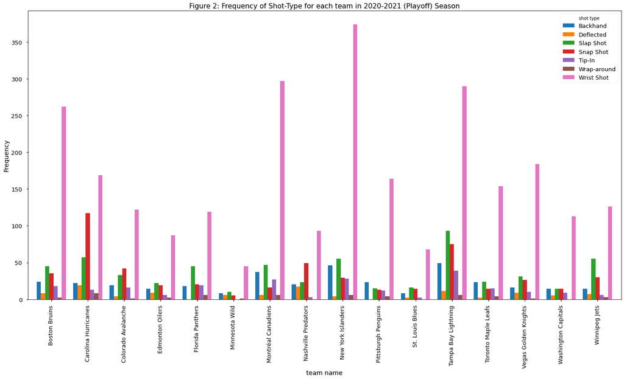

```python
with plt.style.context('seaborn-talk'):
    df.unstack().plot(kind ='bar', width = 0.8, figsize = (24, 12))
    plt.title("Figure 2: Frequency of Shot-Type for each team in 2020-2021 (Playoff) Season")
    plt.ylabel("Frequency")
```

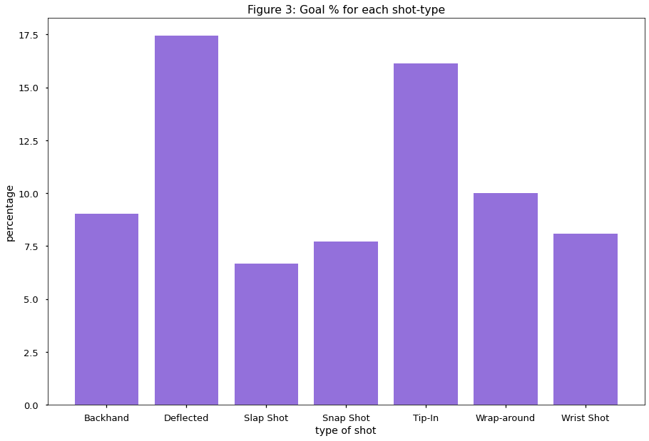

```python
#finding the most lethal shot
goal_perc = (goals / df_hist) * 100
with plt.style.context('seaborn-talk'):
    plt.figure(figsize = (15, 10))
    plt.bar(df_hist.index, goal_perc, color = 'mediumpurple', label = 'Goal %')
    plt.ylabel('percentage')
    plt.xlabel('type of shot')
    plt.title("Figure 3: Goal % for each shot-type")
```

**Discussion**

In this part, we analyse the NHL data from the 2020-2021 (playoff) season.

From *Figure 1* we observe that *Wrist Shot* is the most common type of shot. Being known to be the most accurate type of shot, this result doesn't come as a surprise. However, we wanted to dive a step deeper and observe if this trend is similar across all the teams which indeed it is. An interesting observation is that the players from the teams: {New York Islands, Montreal Canadiens} heavily favor this shot over other shots.

## Part 2

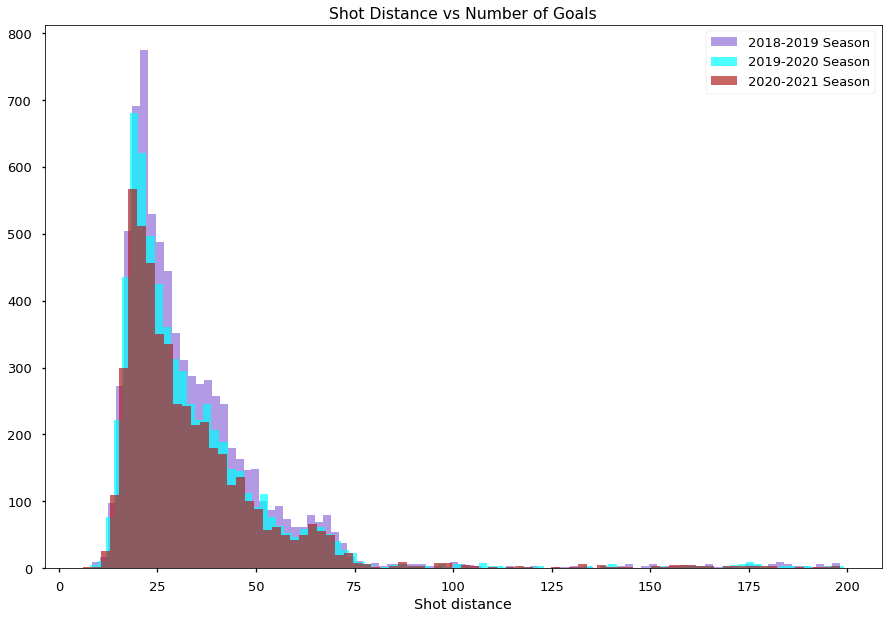

```python
with plt.style.context('seaborn-talk'):
    plt.figure(figsize = (15, 10))
    plt.hist(distances[0], bins = 'auto', color = 'mediumpurple', alpha = 0.7, label = '2018-2019 Season')
    plt.hist(distances[1], bins = 'auto', color = 'aqua', alpha = 0.7, label = '2019-2020 Season')
    plt.hist(distances[2], bins = 'auto', color = 'firebrick', alpha = 0.7, label = '2020-2021 Season')
    plt.legend(loc = 'upper right')
    plt.xlabel('Shot distance')
    plt.ylabel('')
    plt.title('Shot Distance vs Number of Goals')
    plt.show()
```

**Discussion**

We notice that across all the seasons, chances of scoring a goal are the most when the distance from the goal is between 15 and 75. Surprisingly, there is not much change as go from 2018-2019 season to 2020-2021 season.

## Part 3

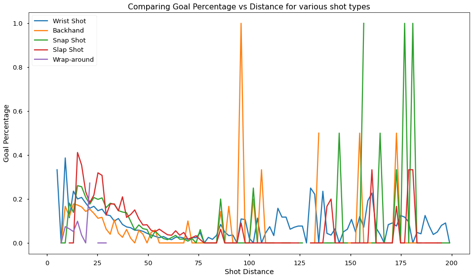

```python
st = ['Wrist Shot', 'Backhand', 'Snap Shot', 'Slap Shot', 'Wrap-around']
with plt.style.context('seaborn-talk'):
    plt.figure(figsize = (16, 9))
    plt.xlabel("Shot Distance")
    plt.ylabel("Goal Percentage")
    plt.title("Comparing Goal Percentage vs Distance for various shot types")

    for i in range(len(goal_perc)):
        plt.plot(bins, goal_perc[i], label = st[i])

    plt.legend(loc = 'upper left')
```

### Discussion

**Methodology**

To compare the *Goal Percentage vs Shot Distance* for different type of shots *(wrist shot, backhand, snap shot, slap shot, wrap around)* we first divide the distance from goal into 100 bins and get the the count of total shots (shot or goal) in that bin using the `matplotlib.pyplot.hist()` function. Then simililarly, for each bin, we get the counts of shots that were goals. To get the goal percentage for each bin, we divide the number of goals with the total number of shots for that bin.

Next, for each shot type, we plot the goal-percentage with the shot-distance. The values of shot-distance are obtained by taking the *center* value of each bin *{(bin start + bin end) / 2)}*

**Observations**

We notice that different type of shots have different level of efficacy depending on the distance from the goal.

For **short range** [0-25] we notice, that *wrist* and *slap* shots are the most lethal. However, their efficacy drops for the distance range: [30-125] but then increases again for distances greater than 125 units.

For **mid range** [30-110], *snap shot* and *backhand* seem to be the most lethal type of shots.

For **long range** [120-200] *backhand*, *snap shot*, and *slap shot* seem to be the most effective type of shots